# Business Forecasting for fish production in United States

# The histogram is slightly right skewed.

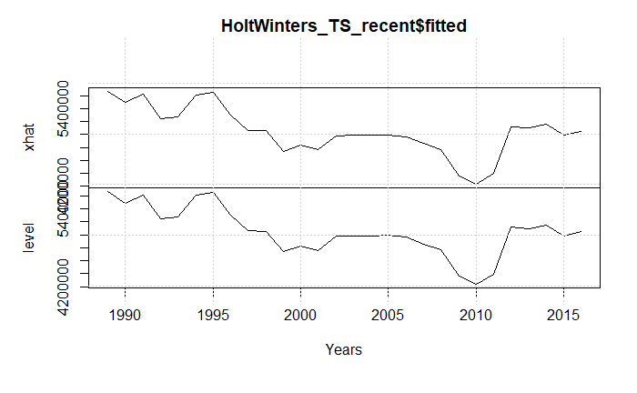

```r
plot(HoltWinters_TS_recent$fitted,HoltWinters_residual, xlab = "Years")
grid(nx=NULL, ny=NULL)
```

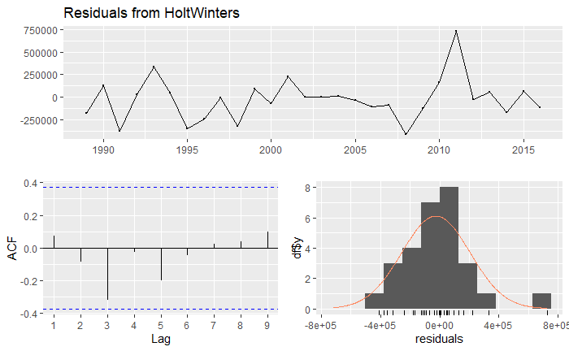

```r
checkresiduals(HoltWinters_TS_recent)
```

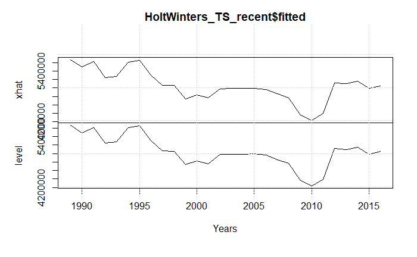

```r
plot.ts(HoltWinters_TS_recent$fitted,HoltWinters_TS_recent$residuals,xy.labels = FALSE,xy.lines = FALSE, xlab = "Years")
grid(nx=NULL, ny=NULL)
```

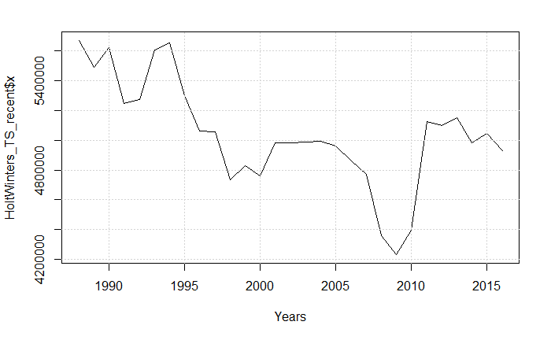

```r
plot.ts(HoltWinters_TS_recent$x,HoltWinters_TS_recent$residuals,xy.labels = FALSE,xy.lines = FALSE, xlab = "Years")
grid(nx=NULL, ny=NULL)
```

```r
HoltWinters_forecast = forecast(HoltWinters_TS_recent,h=3)
HoltWinters_forecast
```

|  | Point Forecast | Lo 80 | Hi 80 | Lo 95 | Hi 95 |
| --- | --- | --- | --- | --- | --- |
| 2017 | 4931025 | 4635287 | 5226762 | 4478733 | 5383316 |
| 2018 | 4931025 | 4512802 | 5349247 | 4291409 | 5570640 |
| 2019 | 4931025 | 4418815 | 5443234 | 4147667 | 5714382 |

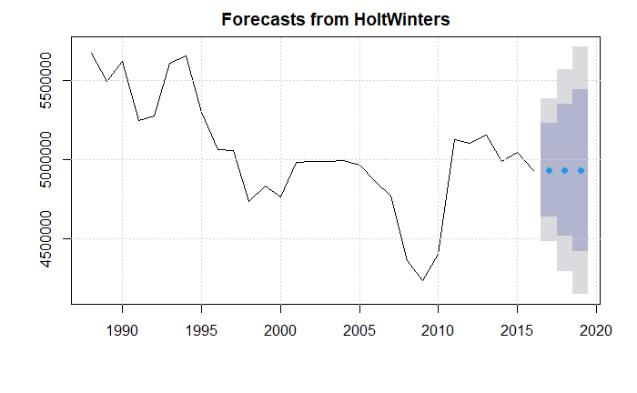

```r
plot(HoltWinters_forecast)
grid(nx = NULL, ny = NULL)
```

```r
accuracy(HoltWinters_forecast)
```

```
                    ME     RMSE      MAE        MPE     MAPE      MASE       ACF1
Training set -26417.51 228141.6 160036.7 -0.6050042 3.205737 0.9999942 0.07209646
```

#HW end

#ARIMA start

```r
ndiffs(FP_US_TS_recent)
```

```
[1] 1
```

# This gives the d value in the Arima function. It tells you the number of differences that you should take to make the time series stationary.

```r
Arima_FP_TS = auto.arima(FP_US_TS_recent, trace = TRUE, stepwise = FALSE)
```

```
 ARIMA(0,1,0)                    : 772.5265
 ARIMA(0,1,0) with drift         : 774.4747
 ARIMA(0,1,1)                    : 774.6563
 ARIMA(0,1,1) with drift         : 776.8304
 ARIMA(0,1,2)                    : 777.1605
 ARIMA(0,1,2) with drift         : 779.5101
 ARIMA(0,1,3)                    : 775.9411
 ARIMA(0,1,3) with drift         : Inf
 ARIMA(0,1,4)                    : 778.0335
 ARIMA(0,1,4) with drift         : 780.1718
 ARIMA(0,1,5)                    : Inf
 ARIMA(0,1,5) with drift         : Inf
 ARIMA(1,1,0)                    : 774.6754
 ARIMA(1,1,0) with drift         : 776.8509
 ARIMA(1,1,1)                    : 777.124
 ARIMA(1,1,1) with drift         : 779.4869
 ARIMA(1,1,2)                    : 778.4902
 ARIMA(1,1,2) with drift         : Inf
 ARIMA(1,1,3)                    : 777.0049
 ARIMA(1,1,3) with drift         : Inf
 ARIMA(1,1,4)                    : 780.2771
 ARIMA(1,1,4) with drift         : 782.6818
 ARIMA(2,1,0)                    : 777.0275
 ARIMA(2,1,0) with drift         : 779.3654
 ARIMA(2,1,1)                    : 779.1732
 ARIMA(2,1,1) with drift         : 781.8711
 ARIMA(2,1,2)                    : Inf
 ARIMA(2,1,2) with drift         : Inf
 ARIMA(2,1,3)                    : 780.2759
 ARIMA(2,1,3) with drift         : Inf
 ARIMA(3,1,0)                    : 777.0024
 ARIMA(3,1,0) with drift         : 779.4954
 ARIMA(3,1,1)                    : 779.5692
 ARIMA(3,1,1) with drift         : 782.3931
 ARIMA(3,1,2)                    : 782.1542
 ARIMA(3,1,2) with drift         : Inf
 ARIMA(4,1,0)                    : 779.9306
 ARIMA(4,1,0) with drift         : 782.7314
 ARIMA(4,1,1)                    : 782.8111
 ARIMA(4,1,1) with drift         : Inf
 ARIMA(5,1,0)                    : 781.1797
 ARIMA(5,1,0) with drift         : 783.9138



 Best model: ARIMA(0,1,0)
```

```r
Arima_FP_TS
```

```
Series: FP_US_TS_recent
ARIMA(0,1,0)

sigma^2 estimated as 5.205e+10:  log likelihood=-385.19
AIC=772.37   AICc=772.53   BIC=773.7
```

# It shows that the best model using Arima is (0,1,0) since it has the lowest AIC.

```r
Arima_FP_TS = auto.arima(FP_US_TS_recent, trace = TRUE, stepwise = FALSE, ic = c("bic"))
```

```
 ARIMA(0,1,0)                    : 773.7049
 ARIMA(0,1,0) with drift         : 776.6592
 ARIMA(0,1,1)                    : 776.8408
 ARIMA(0,1,1) with drift         : 779.8271
 ARIMA(0,1,2)                    : 780.1571
 ARIMA(0,1,2) with drift         : 783.0998
 ARIMA(0,1,3)                    : 779.5308
 ARIMA(0,1,3) with drift         : Inf
 ARIMA(0,1,4)                    : 781.9672
 ARIMA(0,1,4) with drift         : 784.165
 ARIMA(0,1,5)                    : Inf
 ARIMA(0,1,5) with drift         : Inf
 ARIMA(1,1,0)                    : 776.8598
 ARIMA(1,1,0) with drift         : 779.8475
 ARIMA(1,1,1)                    : 780.1206
 ARIMA(1,1,1) with drift         : 783.0766
 ARIMA(1,1,2)                    : 782.0799
 ARIMA(1,1,2) with drift         : Inf
 ARIMA(1,1,3)                    : 780.9387
 ARIMA(1,1,3) with drift         : Inf
 ARIMA(1,1,4)                    : 784.2704
 ARIMA(1,1,4) with drift         : 786.4072
 ARIMA(2,1,0)                    : 780.0241
 ARIMA(2,1,0) with drift         : 782.9551
 ARIMA(2,1,1)                    : 782.7629
 ARIMA(2,1,1) with drift         : 785.8048
 ARIMA(2,1,2)                    : Inf
 ARIMA(2,1,2) with drift         : Inf
 ARIMA(2,1,3)                    : 784.2691
 ARIMA(2,1,3) with drift         : Inf
 ARIMA(3,1,0)                    : 780.5921
 ARIMA(3,1,0) with drift         : 783.4291
 ARIMA(3,1,1)                    : 783.503
 ARIMA(3,1,1) with drift         : 786.3864
 ARIMA(3,1,2)                    : 786.1474
 ARIMA(3,1,2) with drift         : Inf
 ARIMA(4,1,0)                    : 783.8644
 ARIMA(4,1,0) with drift         : 786.7247
 ARIMA(4,1,1)                    : 786.8043
 ARIMA(4,1,1) with drift         : Inf
 ARIMA(5,1,0)                    : 785.1729
 ARIMA(5,1,0) with drift         : 787.6392



 Best model: ARIMA(0,1,0)
```

```r
Arima_FP_TS
```

```
Series: FP_US_TS_recent
ARIMA(0,1,0)

sigma^2 estimated as 5.205e+10:  log likelihood=-385.19
AIC=772.37   AICc=772.53   BIC=773.7
```

# This is the same Arima method, that best model using Arima is (0,1,0) considering BIC values.

```r
attributes(Arima_FP_TS)
```

```
$names
 [1] "coef"      "sigma2"    "var.coef"  "mask"      "loglik"    "aic"       "arma"      "residuals"
 [9] "call"      "series"    "code"      "n.cond"    "nobs"      "model"     "bic"       "aicc"
[17] "x"         "fitted"

$class
[1] "forecast_ARIMA" "ARIMA"          "Arima"
```

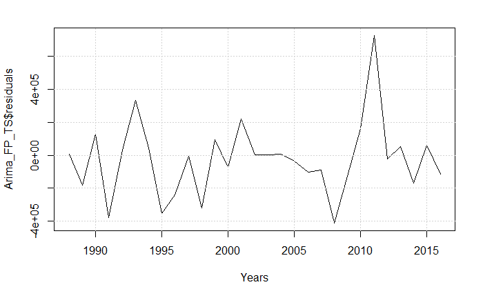

```r
plot(Arima_FP_TS$residuals, xlab = "Years")
grid(nx=NULL, ny=NULL)
```

# The plot is equally spread residuals around the horizontal line without a distinct pattern. This is a good indication it is not a non-linear relationship.

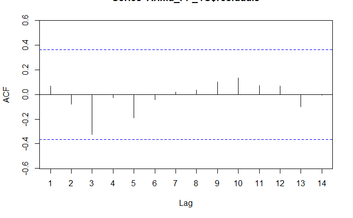

```r
Acf(Arima_FP_TS$residuals)
```

# Here, in the Acf, we don’t see any significant lines which states that there is no correlation between the errors.

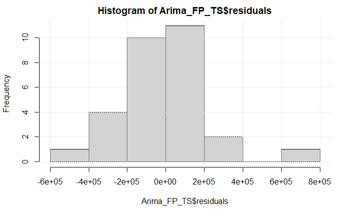

```r
hist(Arima_FP_TS$residuals)
grid(nx=NULL, ny=NULL)
```

# The histogram is right skewed.

```
    Ljung-Box test

data:  Residuals from ARIMA(0,1,0)
Q* = 5.4944, df = 6, p-value = 0.4821

Model df: 0.   Total lags used: 6
```

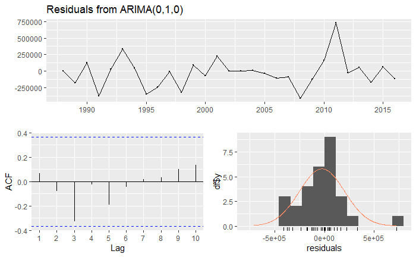

```r
checkresiduals(Arima_FP_TS)
```

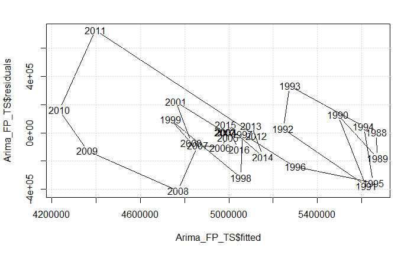

```r
plot(Arima_FP_TS$fitted,Arima_FP_TS$residuals)
grid(nx=NULL, ny=NULL)
```

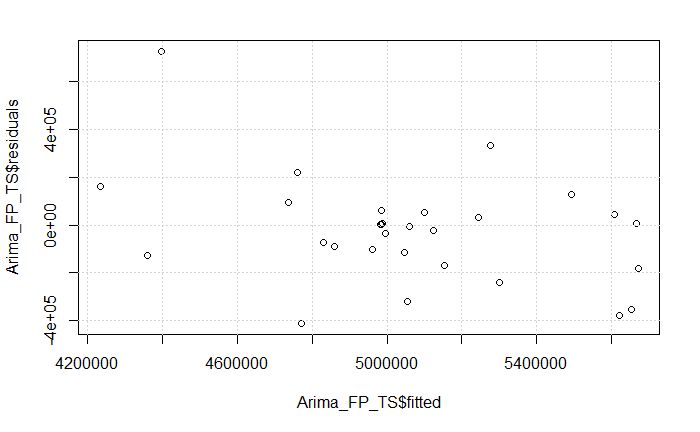

```r
plot.ts(Arima_FP_TS$fitted,Arima_FP_TS$residuals,xy.labels = FALSE,xy.lines = FALSE)
grid(nx=NULL, ny=NULL)
```

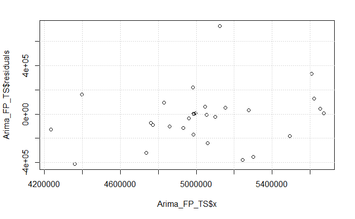

```r
plot.ts(Arima_FP_TS$x,Arima_FP_TS$residuals,xy.labels = FALSE,xy.lines = FALSE)
grid(nx=NULL, ny=NULL)
```